# Monte Carlo Modeling

### Introduction

Monte Carlo simulation is a process using probabilistic technique to generate random values for uncertain inputs then compute the outputs, replicating this process for multiple times to understand the distribution of outputs and their statistical properties (min, max, mean and so on).

In this project, I will apply Monte Carlo method to understand the future of a business decision. The method is commonly used in financial planning & budgeting to forecast the future and support decision making. A model is built to predict financial performance metrics (NPV, profitability, cashflow) in multiple periods. Thought most of finance professionals prefer Excel spreadsheet to run simulation, I prefer Python. I want to practice and hone my skill with Python. It's faster and more convenient.

### Define problem

Suppose that ABC Company has discovered a potential drug breakthrough in the laboratory and needs to decide whether to conduct clinical trials and seek FDA approval to market the drug. Total R&D costs are expected to reach USD 700 million, and the cost of clinical trials will be about USD 150 million. The current market size is estimated to be two million people and is expected to grow at approximately 3% each year. In the first year, ABC estimates gaining an 8% market share, which is anticipated to grow around 20% each year. It is difficult to estimate beyond five years because new competitors are expected to be entering the market. A monthly prescription is anticipated to generate revenue of USD130 while incurring variable costs of USD40.

With a lot of uncertainty, their FP&A team is trying to illustrate different scenarios to predict the profitability of the new product. They are interested in evaluating the risk associated with the project and need to answer 3 questions as follows:

1. What is the risk that the net present value (NPV) over the five years will not be positive?
2. What are the chances that the product will show a positive cumulative net profit in the third year?
3. In the fifth year, what minimum amount of cumulative profit are we likely to achieve with a probability of at least 90%?

Reference: Evans, J. R. (2021). Spreadsheet Modeling and Analysis. In Business analytics: Methods, models, and decisions (pp. 405–440). Pearson.

### Import library

```python
import numpy as np
import pandas as pd
import statistics
import random
import matplotlib.pyplot as plt
%matplotlib inline
```

```python
discount_rate = 0.09
unit_sales = 130
unit_cost = 40
unit_margin = unit_sales - unit_cost
market_size_mean = 2000000
market_size_sd = 40000
clinical_trial_cost_mean = 150000000
clinical_trial_cost_sd = 30000000
rd_cost_lower = 600000000
rd_cost_upper = 800000000
annual_mk_growth_min = .02
annual_mk_growth_mode = .03
annual_mk_growth_max = .06
share_growth_min = .15
share_growth_mode = .2
share_growth_max = .25
iteration = 1000
project_year = 5
```

### Set up code

In this problem, some inputs are uncertain and distributed in different ways. Inputs are normal, uniform and triangular random variates.

Normal distribution: Clinical trial cost, market size.  
Uniform distribution: R&D cost.  
Triangular distribution: annual market growth factor and annual market share growth rate.

For R&D and Clinical trial cost, the random inputs are used in first year only, these expenses presumably to spend all once the project begins. The other inputs like growth rate or market size, the team must use different input values for each year of the model as these values are independent of each other. For example, the code below generate 5 different radom value of share growth rate for 5 years.

```python
share_growth_rate = np.random.triangular(share_growth_min,share_growth_mode,share_growth_max,project_year)
share_growth_rate
```

```
array([0.2196643 , 0.21885991, 0.22675191, 0.20275684, 0.1965074 ])
```

To build the model, we need to understand what is NPV.

"Net present value (NPV) is a financial metric that seeks to capture the total value of a potential investment opportunity. The idea is to project all of the future cash inflows and outflows associated with an investment, discount all those future cash flows to the present day, and then add them together. The resulting number after adding all the positive and negative cash flows together is the investment’s NPV. A positive NPV means that, after accounting for the time value of money, you will make money if you proceed with the investment."

For more information, please check https://www.investopedia.com/terms/n/npv.asp

```python
def project ():
    outputs = []
    for i in range(iteration):
        rd_cost = np.random.uniform(rd_cost_lower,rd_cost_upper) # generate a random value for R&D cost at the beginning
        clinical_trial_cost = np.random.normal(clinical_trial_cost_mean,clinical_trial_cost_sd) # generate a random value, similar to R&D
        project_cost = round((rd_cost + clinical_trial_cost)/1000000) # sum up the investment costs
        share = .08
        mksize = np.random.normal(market_size_mean,market_size_sd) # generate a random value
        share_growth = list(np.random.triangular(share_growth_min,share_growth_mode,share_growth_max,project_year)) # generate random value for each year
        annual_mk_growth = list(np.random.triangular(annual_mk_growth_min,annual_mk_growth_mode,annual_mk_growth_max,project_year)) # generate random value for each year
        yearly_cum_profit = []
        cumulated_profit = 0 - project_cost
        npv_profit = 0
        year = 0
        while year < project_year:
            profit = round((share * mksize *  unit_margin * 12)/1000000)
            cumulated_profit = cumulated_profit + profit
            yearly_cum_profit.append(cumulated_profit)
            npv_profit = npv_profit + round(profit/(1+discount_rate)**(year+1)) #discount all those future cash inflows to the present day, and then add them together
            share = share * (1+share_growth[year])
            mksize = mksize * (1+ annual_mk_growth[year])
            year += 1
        npv_project = round((npv_profit - project_cost)) #project all of the future cash inflows and outflows associated with an investment
        yearly_cum_profit.append(npv_project)
        outputs.append(yearly_cum_profit)
    return outputs
```

### Result table

The first 5 columns describe cumulated profit each year. The last column shows total project NPV after 5 years.

```python
df = pd.DataFrame(project(), columns = ['year1','year2','year3','year4','year5','Total_NPV'])
df.head() #showing first 5 rows
```

|  | year1 | year2 | year3 | year4 | year5 | Total_NPV |
| --- | --- | --- | --- | --- | --- | --- |
| 0 | -662 | -448 | -176 | 163 | 576 | 222 |
| 1 | -624 | -413 | -157 | 170 | 581 | 237 |
| 2 | -673 | -464 | -200 | 132 | 546 | 197 |
| 3 | -623 | -399 | -112 | 253 | 704 | 326 |
| 4 | -560 | -342 | -66 | 271 | 691 | 333 |

```python
df.describe(percentiles=[.95, .75, .5, .25, .05])
```

|  | year1 | year2 | year3 | year4 | year5 | Total_NPV |
| --- | --- | --- | --- | --- | --- | --- |
| count | 1000.000000 | 1000.00000 | 1000.000000 | 1000.000000 | 1000.000000 | 1000.000000 |
| mean | -677.639000 | -462.55800 | -195.231000 | 137.227000 | 550.481000 | 199.672000 |
| std | 64.942515 | 65.26253 | 66.755854 | 70.797215 | 78.506655 | 72.220622 |
| min | -843.000000 | -629.00000 | -366.000000 | -55.000000 | 316.000000 | -9.000000 |
| 5% | -785.000000 | -568.00000 | -306.000000 | 22.950000 | 420.950000 | 80.950000 |
| 25% | -730.000000 | -514.25000 | -246.000000 | 86.000000 | 495.750000 | 149.750000 |
| 50% | -677.000000 | -463.00000 | -195.000000 | 140.000000 | 553.000000 | 202.000000 |
| 75% | -626.000000 | -412.00000 | -146.000000 | 189.000000 | 604.000000 | 250.000000 |
| 95% | -572.950000 | -358.95000 | -88.000000 | 253.000000 | 678.050000 | 321.000000 |
| max | -523.000000 | -304.00000 | -17.000000 | 349.000000 | 803.000000 | 420.000000 |

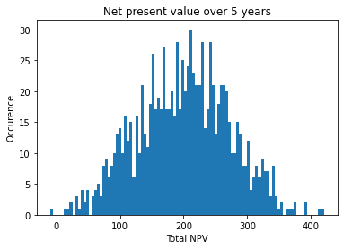

```python
df['Total_NPV'].plot.hist(bins=100)
plt.xlabel("Total NPV")
plt.ylabel("Occurence")
plt.title('Net present value over 5 years')
```

### Analyse the result

What is the probability that the net present value over the 5 years will not be positive?  
To tackle this, we need to calculate P(x < 0) of Total NPV.  
The result shows it is rarely a chance that Total project NPV is negative. It is a profitable project after 5 years.

```python
threshold_x1 = 0
p_x1 = sum(map(lambda x: x < threshold_x1, df['Total_NPV']))/len(df)
p_x1_display = "{:.0%}".format(p_x1)
print('Chance of npv < threshold ' + str(threshold_x1) + 'M is: ' + str(p_x1_display))
```

```
Chance of npv < threshold 0M is: 0%
```

What are the chances that the product will show a cumulative net profit in the third year?  
To tackle this, we need to calculate P(x > 0) in Year 3.  
The result shows it is unlikely that the cumulated net profit is positive in year 3.

```python
threshold_x2 = 0
p_x2 = sum(map(lambda x: x > threshold_x2, df['year3']))/len(df)
p_x2_display = "{:.0%}".format(p_x2)
print('Chance of year 3 cumulated net profit > threshold ' + str(threshold_x2) + 'M is: ' + str(p_x2_display))
```

```
Chance of year 3 cumulated net profit > threshold 0M is: 0%
```

What cumulative profit in the fifth year are we likely to realize with a probability of at least 0.90? Or in the fifth year, what minimum amount of cumulative profit are we likely to achieve with a probability of at least 0.90? ~ we are looking for the 10th percentile

```python
print('90 percent of chance that the cumulated profit in year 5 will larger than ' + str(np.percentile(df['year5'],10)))
```

```
90 percent of chance that the cumulated profit in year 5 will larger than 446.0
```

With the assumption that all investment costs is spent in at the beginning, it starts with a negative cash flow and becomes positive when cumulated profit exceed the initial investment costs. As can be seen from the summary:

- Average cumulated profit (or cash flow) of the project is negative from year 1 to 3, positive from year 4 on ward.
- Average total project NPV is approximately 200M

It is a profitable project over 5 years.